# MachineLearningProject

Aaron Taylor

September 27, 2017

# Practical Machine Learning Course Project

## Background

Using devices such as Jawbone Up, Nike FuelBand, and Fitbit it is now possible to collect a large amount of data about personal activity relatively inexpensively. These type of devices are part of the quantified self movement - a group of enthusiasts who take measurements about themselves regularly to improve their health, to find patterns in their behavior, or because they are tech geeks. One thing that people regularly do is quantify how much of a particular activity they do, but they rarely quantify how well they do it. In this project, your goal will be to use data from accelerometers on the belt, forearm, arm, and dumbell of 6 participants. They were asked to perform barbell lifts correctly and incorrectly in 5 different ways. More information is available from the website here: http://web.archive.org/web/20161224072740/http:/groupware.les.inf.puc-rio.br/har (see the section on the Weight Lifting Exercise Dataset).

## Data

The training data for this project are available here:

https://d396qusza40orc.cloudfront.net/predmachlearn/pml-training.csv

The test data are available here:

https://d396qusza40orc.cloudfront.net/predmachlearn/pml-testing.csv

## Project Objectives

The goal of your project is to predict the manner in which they did the exercise. This is the “classe” variable in the training set. You may use any of the other variables to predict with. You should create a report describing how you built your model, how you used cross validation, what you think the expected out of sample error is, and why you made the choices you did. You will also use your prediction model to predict 20 different test cases.

## Preliminary Work

### Reproduceability

The seed will be set to 12345 for all code. If the same seed is used, it will reproduce the below data.

### How the model was built

The outcome variable is classe, a 5-level factor variable. They correspond to five different excersize activities:

- A: exactly according to the specification
- B: throwing the elbows to the front
- C: lifting the dumbbell only halfway
- D: lowering the dumbbell only halfway
- E: throwing the hips to the front

Class A is the correct version of the exercise, while the other 4 are common mistakes. Three models, Decision Trees, Randoms Forests, and Neural Network will be utilized, and will be evaluated based on maximizing accuracy/minimizing out-of-sample error. All other variables not removed by cleaning will be used for prediction.

### Cross-validation

Cross-validation will be performed by separating the train data set into two parts: trainTrain (60%) and trainTest (40%). Our models will be fitted on the trainTrain data, and tested on the trainTest data. Once the most accurate model is found, it will be tested on the original test data set.

### Expected out-of-sample error

The expected out-of-sample error will correspond to (1 - accuracy) in the cross-validation data. Accuracy is the proportion of correct classified observations over the total sample in the trainTest data set. Expected accuracy is the expected accuracy in the test data set. Thus, the expected value of the out-of-sample error will correspond to the expected number of (missclassified observations/total observations) in the test data, i.e. (1 - accuracy) from the cross-validation data.

Features with majority (>50%) missing values will be discarded as well as features that are irrelevant (columns 1 through 6). All other features will be kept as relevant variables.

## Data Acquisition and Preprocessing

### Data Acquisition

```r
fileUrl1 <- "https://d396qusza40orc.cloudfront.net/predmachlearn/pml-training.csv"
fileUrl2 <- "https://d396qusza40orc.cloudfront.net/predmachlearn/pml-testing.csv"
temp1 <- tempfile()
temp2 <- tempfile()
download.file(fileUrl1, destfile = temp1, mode = "wb")
download.file(fileUrl2, destfile = temp2, mode = "wb")
dateDowloaded <- date()
dateDowloaded
```

```
## [1] "Wed Sep 27 23:32:16 2017"
```

```r
train <- read.csv(temp1, header = TRUE, na.strings=c("NA","#DIV/0!",""))
test <- read.csv(temp2, header = TRUE, na.strings=c("NA","#DIV/0!",""))
unlink(temp1)
unlink(temp2)
```

### Libraries

```r
library(caret)
library(randomForest)
```

```r
library(rpart)
library(rpart.plot)
library(e1071)
```

### Preprocessing

```r
set.seed(12345)
```

Setting the seed for reproducibility reasons.

```r
isNearZero <- nearZeroVar(train, saveMetrics = TRUE)
train <- train[, !isNearZero$nzv]
```

Processing for machine learning is costly; to reduce computing time, we clean from the dataset those variables with a high % of NAs and those characterized by low variance.

```r
NARemove <- sapply(colnames(train), function(x) if(sum(is.na(train[, x])) > 0.50*nrow(train)) {return(TRUE)}
                  else{
                    return(FALSE)
                    })
train <- train[, !NARemove]
```

Removing variables composed of >50% NAs.

```r
train <- train[,-c(1:6)]
```

We remove columns that aren’t important to the machine learning, because otherwise it will screw up the process.

```r
inTrain <- createDataPartition(y=train$classe, p=0.6, list=FALSE)
trainTrain <- train[inTrain, ]
trainTest <- train[-inTrain, ]
```

We create a new pair of training and test data, at a 60/40 proportion, for the purposes of cross-validation. The three models I am using will first be fitted on the trainTrain set, then tested on the trainTest data, in order to figure out which one is the most accurate. The winner will then be applied to the test dataset.

Let’s take a quick look at classe.

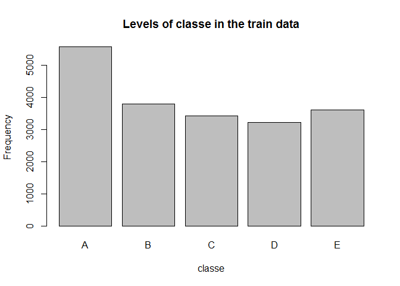

```r
plot(train$classe, main="Levels of classe in the train data", xlab="classe", ylab="Frequency")
```

As we can see, each level frequency is within the same order of magnitude as the others. Level A is the most frequent action while level D is the least frequent.

## Machine Learning Algorithms (MLAs)

I will be using three MLAs: Decision Trees, Random Forests, and a Neural Network. Once these have been generated from the trainTrain set, they will be use to predict the trainTest dataset. The most successful will be used to predict the test dataset.

### Decision Trees

```r
modelDC <- rpart(data = trainTrain, classe ~ ., method = "class")
predictDC <- predict(modelDC, trainTest, type = "class")
```

### Random Forest

```r
modelRF <- train(data = trainTrain, classe ~ ., method = "rf")
predictRF <- predict(modelRF, trainTest)
```

### Neural Network

```r
invisible(capture.output(modelNN <- train(data = trainTrain, classe ~ ., method = "nnet")))
predictNN <- predict(modelNN, trainTest)
```

The extra functions around the modelNN generation are to suppress a great deal of unwanted output.

Now that these have been generated, we can look at the accuracy values in the confusion matrices to see which has the best accuracy.

```r
confusionMatrix(predictDC, trainTest$classe)$overall['Accuracy']
```

```
##  Accuracy
## 0.7267397
```

```r
confusionMatrix(predictRF, trainTest$classe)$overall['Accuracy']
```

```
##  Accuracy
## 0.9927352
```

```r
confusionMatrix(predictNN, trainTest$classe)$overall['Accuracy']
```

```
##  Accuracy
## 0.4432832
```

The best accuracy is Random Forests, with a whopping 99%. Needless to say, we will be applying that to our test dataset.

## Conclusion

Now we apply our Random Forests model to the test dataset, to get our answer for the quiz.

```r
predictTest <- predict(modelRF, test)
predictTest
```

```
##  [1] B A B A A E D B A A B C B A E E A B B B
## Levels: A B C D E
```

## Appendix

### Decision Tree Plot

Just because it looks cool.

[figure not shown]

```r
rpart.plot(modelDC, main="Decision Tree", extra=102, under=TRUE, faclen=0)
```